# Multiple linear regression

Alessandro Bramucci

# Exercise C1 - Chapter 3[^1]

A problem of interest to health officials (and others) is to determine the effects of smoking during pregnancy on infant health. One measure of infant health is birth weight; a birth weight that is too low can put an infant at risk for contracting various illnesses. Since factors other than cigarette smoking that affect birth weight are likely to be correlated with smoking, we should take those factors into account. For example, higher income generally results in access to better prenatal care, as well as better nutrition for the mother. An equation that recognizes this is.

$$bwght = \beta_0 + \beta_1 cigs + \beta_2 faminc + u$$

1. What is the most likely sign for $\beta_2$?

Probably positive because better food means better conditions for the baby and therefore higher birth weight.

2. Do you think cigs and faminc are likely to be correlated? Explain why the correlation might be positive or negative. Calculate the sample correlation.

The correlation is probably negative because more income means more education and more attention to nutrition and health. But also the opposite sign can be expected since more income means increase in consumption.

```r
cor(bwght$faminc , bwght$cigs)
## [1] -0.1730449
```

# Exercise C2 - Chapter 3[^2]

Use the data in HPRICE1.RAW to estimate the model where price is the house price measured in thousands of dollars.

$$price = \beta_0 + \beta_1sqrft + \beta_2bdrms + u$$

2. What is the estimated increase in price for a house with one more bedroom, holding square footage constant?

```r
model3$coefficients[3]*1
## hprice1$bdrms
##      15.19819
```

Holding square footage constant one bedroom increases the price by 15.20 which is $15’200.

3. What is the estimated increase in price for a house with an additional bedroom that is 140 square feet in size? Compare this to your answer in part (ii).

```r
model3$coefficients[3]*1 + model3$coefficients[2]*1*140
## hprice1$bdrms
##      33.17926
```

Now the house is much bigger now therefore the price is going to be higher, approx. $33’180 more.

4. What percentage of the variation in price is explained by square footage and number of bedrooms?

$$R^2 = 0.6319$$

22. The first house in the sample has sqrft = 2438 and bdrms = 4. Find the predicted selling price for this house from the OLS regression line.

```r
fitted_h1 <- model3$coefficients[1] + model3$coefficients[2]*(2438) + model3$coefficients[3]*1*(4)

fitted_h1*1000
## (Intercept)
##    354605.2
```

6. The actual selling price of the first house in the sample was $300’000 (so price = 300). Find the residual for this house. Does it suggest that the buyer underpaid or overpaid for the house according to the model?

```r
# The price of the first house in the sample:
hprice1$price[1]*1000
## [1] 3e+05

# y - y_hat or "observed" minus fitted value
(hprice1$price[1] - fitted_h1)*1000
## (Intercept)
##   -54605.25
```

# Model with quadratic

In this model, we cannot interpret the partial effect of experience on hourly wage, keeping experience squared constant. For this reason, in order to interpret the partial effect of experience on wage we have to differentiate the wage function with respect to experience. By including the squared experience term we are able to capture the diminishing effect of experience on wage. After which years of experience the returns of experience on hourly wage start to become negative?

$$wage = \beta_0 + \beta_1 exper + \beta_2 exper^2 + u$$

$$\frac{\delta wage}{\delta exper} = \beta_1 + 2\beta_2 exper$$

$$\beta_1 + 2\beta_2 exper = 0$$

$$exper = - \frac{\beta_1}{(2\beta_2)}$$

```r
reg <- lm(wage1$wage ~ wage1$exper + I(wage1$exper^2))

beta1 <- reg$coefficients[2]

beta2 <- reg$coefficients[3]

# A first year of experience increase wage by (dollar cents):
beta1 + beta2*2*1
## wage1$exper
##   0.2858403

# However, if a person has already 10 years of experience an additional year of experience, yields a smaller return on hourly wage (dollar cents):
beta1 + beta2*2*10
## wage1$exper
##   0.1755024

# After 24 years of experience an additional year of experience will provide a negative yield on hourly wage.
maximum <- beta1 / (-2*beta2)
maximum
## wage1$exper
##     24.3153

# Just to check..
beta1 + beta2*2*23
## wage1$exper
##  0.01612529
beta1 + beta2*2*24
## wage1$exper
## 0.003865512
beta1 + beta2*2*maximum
## wage1$exper
##           0
beta1 + beta2*2*25
##  wage1$exper
## -0.008394263
beta1 + beta2*2*26
## wage1$exper
## -0.02065404
```

```
##
## ========================================
##                  Dependent variable:
##              ---------------------------
##                         wage
## ----------------------------------------
## exper                 0.298***
##                        (0.041)
##
## exper2)               -0.006***
##                        (0.001)
##
## Constant              3.725***
##                        (0.346)
##
## ----------------------------------------
## Observations             526
## R2                      0.093
## ========================================
## Note:        *p<0.1; **p<0.05; ***p<0.01
```

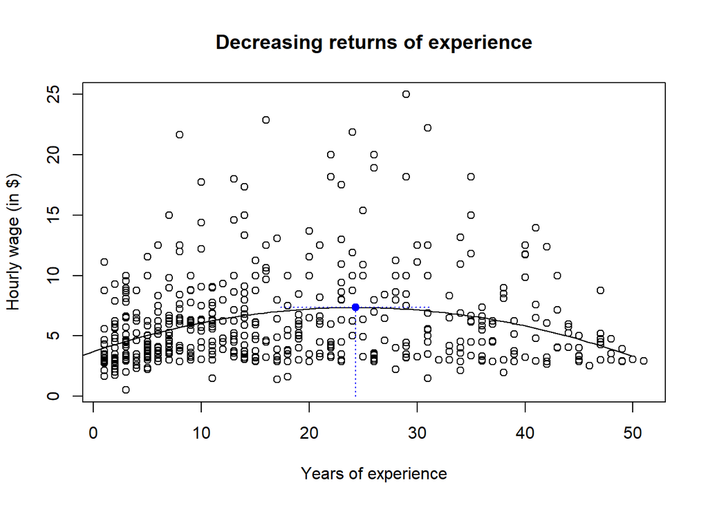

[^1]: Exercise from the book *Introductory Econometrics. A Modern Approach*, by Jeffrey M. Wooldridge.
[^2]: See previous footnote.